# Non-Linear Least Squares

Author

Natalie Smith

# 1 Overview:

Farmers need to understand the biology of plants and their responses to fertilizers to maximize yield. This analysis aims to help farmers predict yields by running non-linear least squares on experimental growth data for three grains in Greece. Additionally, it assesses the response of the grains to fertilizer inputs.

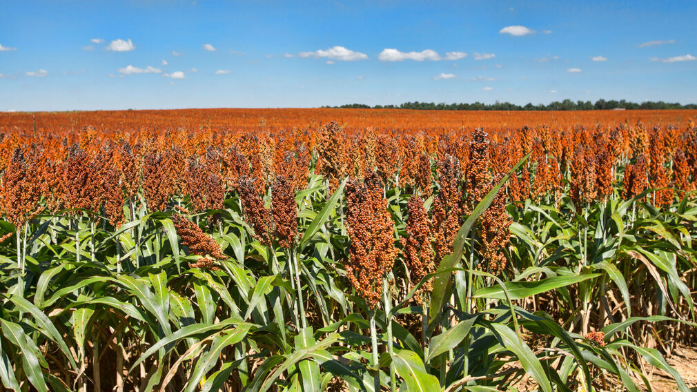

Sorghum, O&Fmagazine

Data Citation:

Archontoulis, S.V. and Miguez, F.E. (2015), Nonlinear Regression Models and Applications in Agricultural Research. Agronomy Journal, 107: 786-798.

```r
library(tidyverse)
library(knitr)
library(broom)
library(kableExtra)
library(nlraa)
library(janitor)
library(patchwork)
```

The dataset we will be using contains crop data with the following variables:

```r
# Create a data frame for variables
variables <- data.frame(
  Variable = c("DOY", "Block", "Input", "Crop", "Yield"),
  Description = c("Day of Year", "Location", "Irrigation & Fertilizer application (High or Low)",
                  "Type of crop: Fiber sorghum (F), Sweet sorghum (S), or Maize (M)",
                  "Biomass (Mg/ha)")
)

# Create kable table
variables_kable <- kable(variables) %>%
  kable_styling()

variables_kable
```

| Variable | Description |
| --- | --- |
| DOY | Day of Year |
| Block | Location |
| Input | Irrigation & Fertilizer application (High or Low) |
| Crop | Type of crop: Fiber sorghum (F), Sweet sorghum (S), or Maize (M) |
| Yield | Biomass (Mg/ha) |

```r
# save_kable(variables_kable, "plots/variables_kable_table.html")
```

# 2 Write Beta Function:

After bringing in the data, and cleaning it up we need to choose a model for our NLS process. Of the 77 potential functions in the paper, we will be using the Beta function:

$$y = ymax (1 + \frac{te - t}{te - tm})\left(\frac{t}{te}\right)^{\frac{te}{te - tm}}$$

The parameters for the beta function are described below:

```r
# Access the data from SM package in NLRAA
data <- sm
#clean the data
crop_df <- data %>%
  janitor::clean_names()
```

```r
# Create a data frame with the parameters
beta_parameters <- data.frame(
  Parameter = c("Y", "Ymax", "t", "tm", "te"),
  Description = c("Response variable (e.g., biomass)", "Asymptotic or maximum Y value",
                  "Explanatory variable (e.g., day of year)",
                  "Inflection point at which the growth rate is maximized",
                  "Time when Y = Yasym")
)

# Create kable table
beta_table <- kable(beta_parameters) %>%
  kable_styling()

beta_table
```

| Parameter | Description |
| --- | --- |
| Y | Response variable (e.g., biomass) |
| Ymax | Asymptotic or maximum Y value |
| t | Explanatory variable (e.g., day of year) |
| tm | Inflection point at which the growth rate is maximized |
| te | Time when Y = Yasym |

```r
# Create beta function:
beta<- function(ymax, te, tm, t){
  y <- ymax * (1 + (te - t) / (te - tm)) * (t / te)^(te / (te - tm))
  return(y)
}
```

# 3 Exploratory Plot:

To find some potential starting parameter values for our NLS analysis, we created an exploratory similar to Fig. 4 (biomass over time).

```r
# Plot
guess_plot <- ggplot(crop_df, aes(x = doy, y = yield, color = "data")) +
  geom_point() +
  geom_smooth()+
  facet_grid(. ~ input, scales = "free_y", space = "free_x")+
  scale_color_manual(values = c("data" = "black", "model" = "#FF5733")) +
  labs(y = "Biomass (mg/ha)", x = "Day of Year", color = " ")+
  theme_minimal()
```

```r
# Guesses as frames to easily inset them later
ymax_guess <- 20
te_guess <- 240
tm_guess <- 200

# Add inital guesses:
beta_test <- crop_df %>%
  mutate(sim=beta(ymax = 20, te = 240, tm = 220, t= doy))
```

# 4 One Crop NLS:

Next, we filter to keep the observations from only the sorghum fields (S) with high inputs (2) and run an NLS model to predict yield for any given day of the year.

```r
# Filter to keep observations from the sorghum fields with high inputs
crop_filter <- crop_df %>%
  filter((crop == "S") & input == 2)
```

```r
nls_1 <- nls(
  formula = yield ~ beta(ymax, te, tm, doy),
  data = crop_filter,
  start = list(ymax = ymax_guess, te = te_guess, tm = tm_guess),
  trace = FALSE)
```

Below is a “good looking table” showing the selected parameter values as well as a graph:

```r
# Create a summary table
summary_table <- coefficients(summary(nls_1))

# Basic table
cute_kable <- kable(summary_table)

# Fancy table
fancy_kable <- kable(summary_table, align = "lccc", digits = 3,
                     col.names = c("Parameter",
                                   "Estimate",
                                   "Standard Error",
                                   "T-value",
                                   "P-value")) %>%
               kable_styling()

fancy_kable
```

| Parameter | Estimate | Standard Error | T-value | P-value |
| --- | --- | --- | --- | --- |
| ymax | 39.820 | 2.249 | 17.707 | 0 |
| te | 281.586 | 2.081 | 135.329 | 0 |
| tm | 244.777 | 3.512 | 69.698 | 0 |

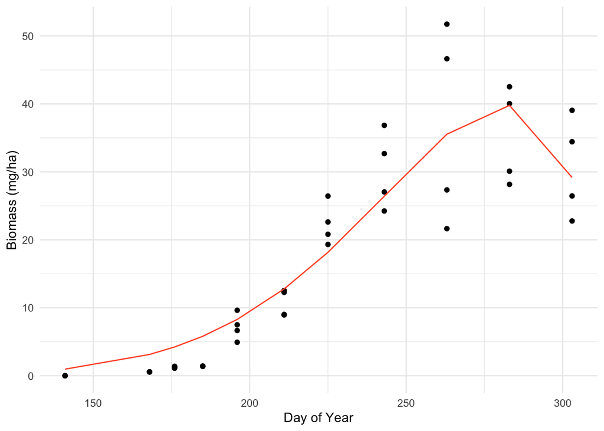

Figure 1: Non-linear Least Squares with the beta function model showcasing a strong fit to the crop data.

```r
crop_predict <- crop_filter %>%
  mutate(predict=predict(nls_1,newdata=.))

ggplot(data=crop_predict)+
  geom_point(aes(x=doy, y=yield))+
  geom_path(aes(x=doy, y=predict),color="#FF5733")+
  labs(y = "Biomass (mg/ha)", x = "Day of Year", color = " ")+
  theme_minimal()
```

# 5 Replicate the using Purrr:

We now need to run our NLS models for all 24 combinations of plot, input level, and crop type using purrr.

```r
#Define a new function to pass along the nls calls

all_nls <- function(test_df) {
  nls(yield ~ beta(ymax, te, tm, doy),
      data = test_df,
      start = list(ymax = ymax_guess, te = te_guess, tm = tm_guess))
}

# Replicate w Purrr
all_crops <- crop_df %>%
  group_by(block,input,crop) %>%
  nest() %>%
  mutate(nls_model = map(data, ~ all_nls(.x))) %>%
  mutate(predictions = map2(nls_model, data, ~ predict(.x, newdata = .y))) %>%
  mutate(rmse = map2_dbl(predictions, data, ~ Metrics::rmse(.x, .y$yield))) %>%
  mutate(smooth = map(nls_model, ~predict(.x, newdata = list(doy = seq(147,306)))))

# all_crops
```

The table below displays the lowest RMSE and the best-fitted models for each species:

```r
# Calculate minimum RMSE for each crop
rmse_table <- all_crops %>%
  group_by(crop) %>%
  summarize(rmse = min(rmse))

# Filter data for crops w lowest RMSE
low_rmse <- all_crops %>%
  filter(rmse %in% rmse_table$rmse)

# Coefficients for each crop
low_rmse_M <- broom::tidy(low_rmse$nls_model[[1]]) %>% mutate(crop="Maize (M)")
low_rmse_S <- broom::tidy(low_rmse$nls_model[[2]]) %>% mutate(crop="Sweet sorghum (S)")
low_rmse_F <- broom::tidy(low_rmse$nls_model[[3]]) %>% mutate(crop="Fiber sorghum (F)")

# Combine data for all crops
low_rmse_combined <- bind_rows(low_rmse_M, low_rmse_S, low_rmse_F)

# Crop to the front
low_rmse_combined <- low_rmse_combined[, c("crop", setdiff(names(low_rmse_combined), "crop"))]

# Kable Table, Baby!
low_rmse_kable <- kable(low_rmse_combined) %>% kable_styling()

low_rmse_kable
```

| crop | term | estimate | std.error | statistic | p.value |
| --- | --- | --- | --- | --- | --- |
| Maize (M) | ymax | 18.93110 | 0.8396975 | 22.54515 | 5.0e-07 |
| Maize (M) | te | 252.57493 | 1.8691750 | 135.12642 | 0.0e+00 |
| Maize (M) | tm | 225.22838 | 1.9262837 | 116.92379 | 0.0e+00 |
| Sweet sorghum (S) | ymax | 31.34739 | 2.0479969 | 15.30636 | 1.2e-06 |
| Sweet sorghum (S) | te | 278.34652 | 1.8171256 | 153.17957 | 0.0e+00 |
| Sweet sorghum (S) | tm | 245.77418 | 3.8150204 | 64.42277 | 0.0e+00 |
| Fiber sorghum (F) | ymax | 29.05637 | 1.6576349 | 17.52881 | 5.0e-07 |
| Fiber sorghum (F) | te | 280.42964 | 1.8389564 | 152.49390 | 0.0e+00 |
| Fiber sorghum (F) | tm | 244.99873 | 3.5385449 | 69.23714 | 0.0e+00 |

```r
# # Save kable
# save_kable(low_rmse_kable, "plots/low_rmse_kable.html")
```

# 6 Plot it:

To plot the data effectively, we’ll:

- Exclude maize data after day 263, as there’s a noticeable dip.
- Create new dataframes to incorporate the filtered data for each input level.
- Filter by block 1

```r
# Unnest predictions from data and clean maize data
un_df <- all_crops %>%
  filter(block==1) %>%
  tidyr::unnest(smooth) %>%
  mutate(doy=seq(147,306)) %>%
  filter(!(doy>263 & crop=="M"))

# Create a dataframe to add corn data
hi_filter <- crop_df %>%
  filter(block == 1 & input == 2)

low_filter <- crop_df %>%
  filter(block == 1 & input == 1)
```

```r
# Make graphs
hi_plot <- un_df %>%
  filter(block == 1 & input == 2) %>%
  ggplot() +
  geom_point(data = hi_filter, aes(x = doy, y = yield, shape = crop)) +
  geom_line(aes(x = doy, y = smooth, linetype = crop)) +labs(y = "Biomass (Mg/ha)", x = "Day of Year", color = " ")+
  theme_minimal()

# hi_plot


low_plot<-un_df |>
  filter(block==1 & input==1) |>
  ggplot()+
  geom_point(data=low_filter,aes(x=doy,y=yield,shape=crop))+
  geom_line(aes(x=doy,y=smooth,linetype=crop))+
 labs(y = " ", x = "Day of Year", color = " ")+
  theme_minimal()

# low_plot
```

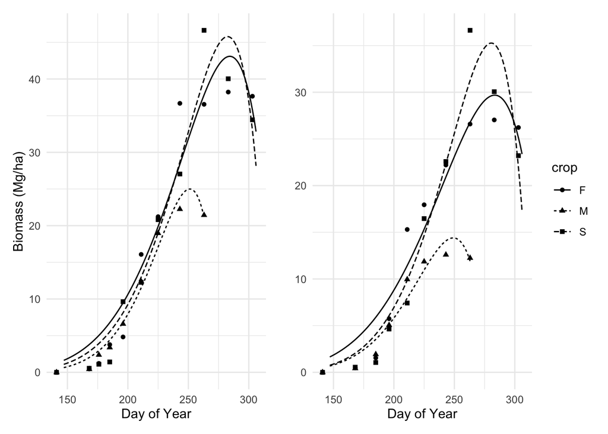

Figure 2: Combined plot illustrating the relationship between fertilizer inputs and yields for all three grains, demonstrating higher yields with increased fertilizer inputs. The left graph represents high fertilizer inputs, while the right graph depicts low fertilizer inputs.

```r
#combine plots - clean up axis first

plot1 <- hi_plot
plot2 <- low_plot

combinedplot <- plot1 + plot2 +
               plot_layout(guides = "collect")

combinedplot
```